# Window analysis game-by-game and player level

Austin Stephen

7/19/2021

### Take Aways:

- This is not capturing the refractory period due to fatigue (shows opposite actually).
- This looks good for our rolling avg as a proxy for team strength as current performance is closely tied to performance over the last 5 games.
- Need to do new windows of speed because it is time adjusted and this might help avoid players getting used more.

#### About the data:

Each observation is a single player in a single game. All players who were in the game for less than 15 seconds were removed. In total, It has 24k observations from the 2014-15 regular season.

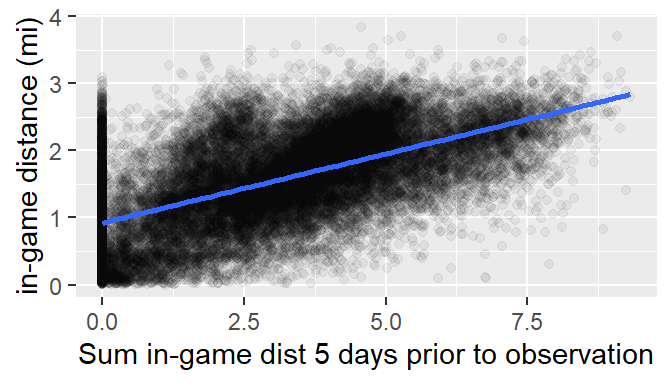

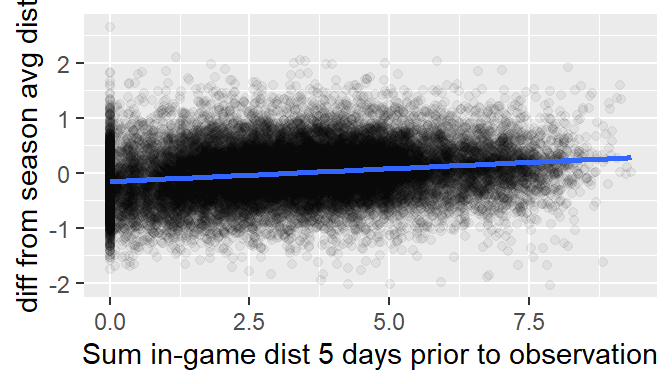

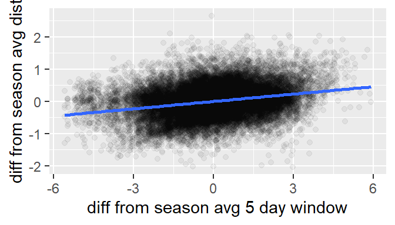

1. *dist_miles* = $\beta_{0}$ + $\beta_{1}$ (*Sum_of_dist_5_days_prior*)  
   p-value $\beta_{1}$ : <2e-16 (t statistic 115.2)
2. *diff_from_season_avg_distance* = $\beta_{0}$ + $\beta_{1}$ (*Sum_of_dist_5_days_prior*)  
   p-value $\beta_{1}$ : <2e-16 (t statistic 31.93)
3. *diff_from_season_avg_distance* = $\beta_{0}$ + $\beta_{1}$ (*diff_from_season_avg_window_last_5_games*)  
   p-value $\beta_{1}$ : <2e-16 (t statistic 41.910)

### Testing window sizes of 3, 5, 7, 10 days

- No difference

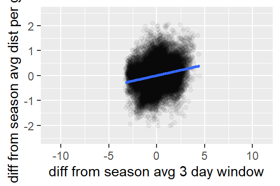

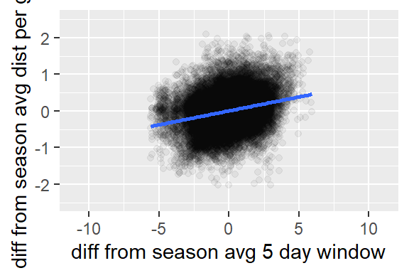

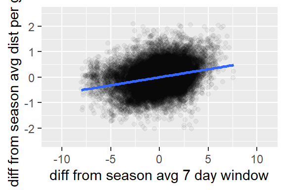

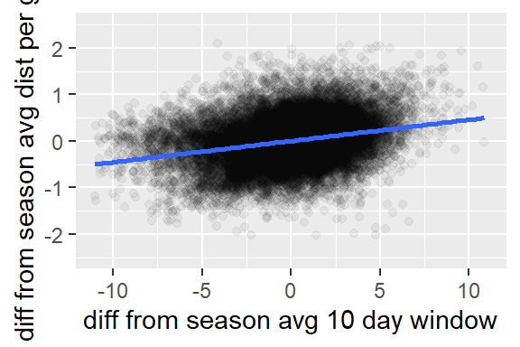

### Only players who played more than 10 minutes

- no difference in relationship

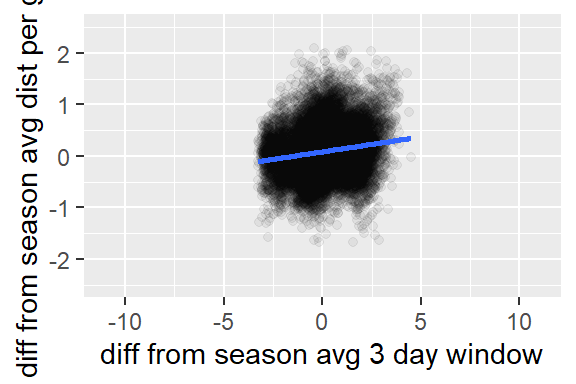

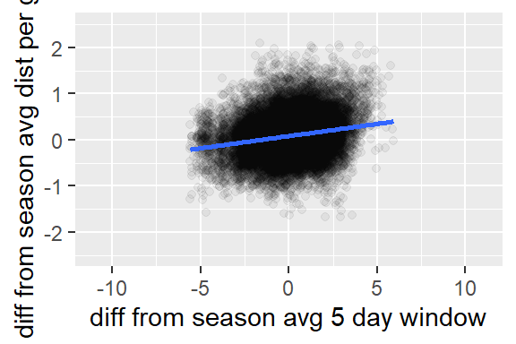

### Relationship with preformance

- Since we showed distance to be positively correlated with fg and fg3 percentage this small positive correlation makes sense.

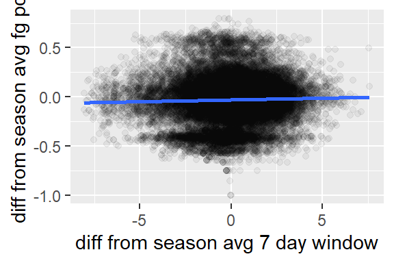

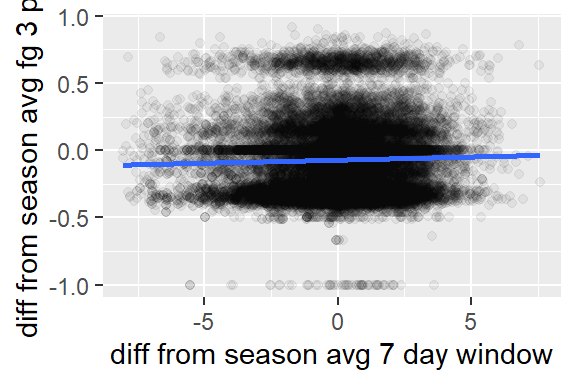

1. *diff_from_season_avg_fg_pct* = $\beta_{0}$ + $\beta_{1}$ (*diff_sn_avg_wind_7_dist*)  
   p-value $\beta_{1}$ : 1.55e-08 (t statistic 5.658)
2. *diff_from_season_avg_fg3_pct* = $\beta_{0}$ + $\beta_{1}$ (*diff_sn_avg_wind_7_dist*)  
   p-value $\beta_{1}$ : 5.42e-07 (t statistic 5.012)

### Reltationship between travel distance and in-game distance

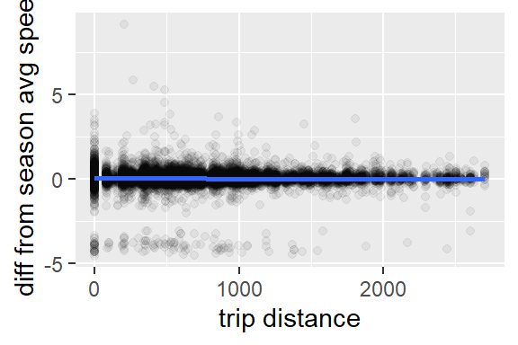

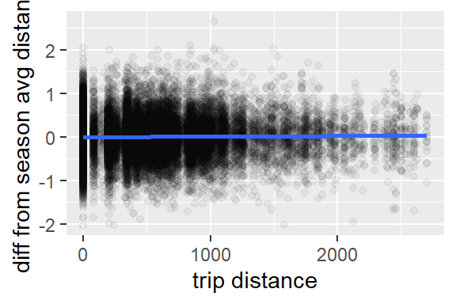

1. *diff_from_sn_avg_speed* = $\beta_{0}$ + $\beta_{1}$ (*distance_team_traveled_pre_game*)  
   p-value $\beta_{1}$ : 0.718 (t statistic -0.362)
2. *diff_from_sn_avg_dist* = $\beta_{0}$ + $\beta_{1}$ (*distance_team_traveled_pre_game*)  
   p-value $\beta_{1}$ : 0.0215 (t statistic 2.3)